# Initial Results and Code for CIND820 PT2

```r
#install.packages("DescTools")
#install.packages("rcompanion") #posthoc chi-square test
#install.packages("FSA")
#install.packages("rstatix")
#install.packages("FSinR")
#install.packages("arules")
#install.packages("arulesViz")
#install.packages("psych")
#install.packages("vcd")
#install.packages("samplesizeCMH")
#install.packages("reshape2")
#install.packages("caret")
#install.packages("naivebayes")
#install.packages("nnet")
#install.packages("randomForest")
#install.packages("ROSE")
#install.packages("ranger")
#install.packages("parsnip")
#install.packages("e1071")
#install.packages("neuralnet")
#install.packages("caTools")
#install.packages("Metrics")
#install.packages("mlr")
#install.packages("Boruta")
#install.packages("tuneRanger")
#install.packages("tidyverse")
#install.packages("leaps")
#install.packages("RCurl")
```

```r
library(tidyverse) #utility functions
library(readxl) #reading xml files
library(jsonlite) # reading json
library(DescTools) #Cramer's V and CMH test
library(rcompanion) #posthoc chi square and CMH tests
library(vcd)
library(psych) #CMH tests
library(rstatix)
library(reshape2)
library(ggplot2) #graphs etc
library(reshape2) #melting for cm matrix
library(corrplot)
library(car)
library(mlbench) #feature selection
library(caret) # feature selection
library(FSinR) #GINI index
library(MASS) # stepwise regression
library(leaps) # all subsets regression
library(RCurl) #regression
library(party) # decision tree
library(arules) #association rules
library(arulesViz) #association rules
library(cluster) #graphing k-means clusters
#install.packages("fpc")
library(fpc) #graphing k-means clusters
library(randomForest)
library(strucchange) #sig of decision tree
```

Loading the cleaned dataset from ‘data_cleaning_descriptivestats_CIND820’ to the local environment.

```r
data <- read.csv(file="C:/Users/mmkea/Documents/brfss_2015_data_clean.csv",
                      stringsAsFactors=FALSE,
                      na.strings=c("","NA"))
```

PLEASE SEE PT1 FOR DESCRIPTIVE ANALYTICS.

Now, let’s use a spearman correlation matrix to check for high variable correlations.

```r
#Creating spearman matrix.
cm <- round(cor(data, method="spearman", use = "complete.obs")
            , 2)

#Removing doubled info.
cm[lower.tri(cm)]<-NA
diag(cm)<-NA

#Reshaping and melting.
cm2 <- na.omit(melt(cm))

#Removing negligible variables.
cm2[cm2$value>=0.2,]
```

```
##           Var1      Var2 value
## 44         SEX   MARITAL  0.20
## 306  X_AGEG5YR   EMPLOY1  0.42
## 351   X_EDUCAG   INCOME2  0.38
## 389    MARITAL  RENTHOM1  0.25
## 431        SEX  VETERAN3  0.54
## 528   X_RFHLTH  PHYSHLTH  0.41
## 571   X_RFHLTH  MENTHLTH  0.20
## 572   PHYSHLTH  MENTHLTH  0.26
## 737     X_BMI5 X_RFHYPE5  0.23
## 792  X_RFHYPE5  X_RFCHOL  0.22
## 968  X_ASTHMS1  CHCCOPD1  0.24
## 1228 X_DRDXAR1  QLACTLM2  0.28
## 1229  ADDEPEV2  QLACTLM2  0.20
## 1276  QLACTLM2  USEEQUIP  0.37
## 1358  ADDEPEV2    DECIDE  0.26
## 1362  QLACTLM2    DECIDE  0.22
## 1495 X_FRUTSUM X_VEGESUM  0.38
## 1496  BEANDAY_ X_VEGESUM  0.42
## 1596 X_AGEG5YR  PA1VIGM_  0.38
## 1627   PA1MIN_  PA1VIGM_  0.74
## 1686   INCOME2     ADULT  0.26
## 1770  X_EDUCAG   AVGDRNK  0.24
## 1772   INCOME2   AVGDRNK  0.27
```

PA1MIN_ and PA1VIGM_ are highly correlated with each other (r = 0.74).

Since PA1MIN_ and PA1VIGM_ both have large volumes of NA values, are highly correlated, and not significantly related to X_RFHLTH, I’m going to remove them from the dataset.

```r
data <- subset(data, select=-c(PA1MIN_, PA1VIGM_))
head(data)
```

```
##   SEX MARITAL CHILDREN X_RACE X_AGEG5YR X_BMI5 X_EDUCAG EMPLOY1 INCOME2
## 1   2       1        0      1         9  40.18        2       2       3
## 2   2       1        1      1         9  28.19        2       2       8
## 3   2       1        0      1         9  24.37        3       2       0
## 4   2       3        0      1        11  26.52        1       1       6
## 5   2       3        0      7        11  23.89        3       3       4
## 6   1       1        0      1        13  33.82        1       2       3
##   RENTHOM1 VETERAN3 X_RFHLTH PHYSHLTH MENTHLTH HLTHPLN1 MEDCOST CHECKUP1
## 1        1        2        2       15       18        1       2        1
## 2        1        2        2       30       30        1       1        1
## 3        1        2        2       20        0        1       2        1
## 4        1        2        1        0        0        1       2        1
## 5        1        2        1        0        3        1       2        1
## 6        1        1        2        8        0        1       1        1
##   X_RFHYPE5 X_RFCHOL X_MICHD CVDSTRK3 X_ASTHMS1 CHCCOPD1 X_DRDXAR1 ADDEPEV2
```

[output cut: 20 more lines]

Now that we’ve taken a look at our attributes and their relationship with general health, let’s prepare for the predictive modelling. First, we’ll normalize the attributes of the dataset.

```r
#Creating the function.
normalize <- function(x){
  return ((x - min(x, na.rm=TRUE)) / (max(x, na.rm=TRUE) - min(x, na.rm=TRUE)))
}

#Normalizing the train and test sets.
data_norm <- as.data.frame(lapply(data, normalize))
head(data_norm)
```

```
##   SEX MARITAL CHILDREN    X_RACE X_AGEG5YR    X_BMI5  X_EDUCAG   EMPLOY1
## 1   1     0.0     0.00 0.0000000       0.0 0.7794118 0.3333333 0.3333333
## 2   1     0.0     0.25 0.0000000       0.0 0.3595938 0.3333333 0.3333333
## 3   1     0.0     0.00 0.0000000       0.0 0.2258403 0.6666667 0.3333333
## 4   1     0.4     0.00 0.0000000       0.5 0.3011204 0.0000000 0.0000000
## 5   1     0.4     0.00 0.8571429       0.5 0.2090336 0.6666667 0.6666667
## 6   0     0.0     0.00 0.0000000       1.0 0.5567227 0.0000000 0.3333333
##   INCOME2 RENTHOM1 VETERAN3 X_RFHLTH  PHYSHLTH MENTHLTH HLTHPLN1 MEDCOST
## 1   0.375        0        1        1 0.5000000      0.6        0       1
## 2   1.000        0        1        1 1.0000000      1.0        0       0
## 3   0.000        0        1        1 0.6666667      0.0        0       1
## 4   0.750        0        1        0 0.0000000      0.0        0       1
## 5   0.500        0        1        0 0.0000000      0.1        0       1
## 6   0.375        0        0        1 0.2666667      0.0        0       0
##   CHECKUP1 X_RFHYPE5 X_RFCHOL X_MICHD CVDSTRK3 X_ASTHMS1 CHCCOPD1 X_DRDXAR1
```

[output cut: 20 more lines]

After normalization, we’ll impute the missing data with a multiple imputation package from MICE.

```r
#install.packages("mice")
set.seed(1)
library(mice)
temp_data_norm <- mice(data_norm, m=1)
data_norm_imp <- complete(temp_data_norm, 1)
head(data_norm_imp)
```

```
##   SEX MARITAL CHILDREN    X_RACE X_AGEG5YR    X_BMI5  X_EDUCAG   EMPLOY1
## 1   1     0.0     0.00 0.0000000       0.0 0.7794118 0.3333333 0.3333333
## 2   1     0.0     0.25 0.0000000       0.0 0.3595938 0.3333333 0.3333333
## 3   1     0.0     0.00 0.0000000       0.0 0.2258403 0.6666667 0.3333333
## 4   1     0.4     0.00 0.0000000       0.5 0.3011204 0.0000000 0.0000000
## 5   1     0.4     0.00 0.8571429       0.5 0.2090336 0.6666667 0.6666667
## 6   0     0.0     0.00 0.0000000       1.0 0.5567227 0.0000000 0.3333333
##   INCOME2 RENTHOM1 VETERAN3 X_RFHLTH  PHYSHLTH MENTHLTH HLTHPLN1 MEDCOST
## 1   0.375        0        1        1 0.5000000      0.6        0       1
## 2   1.000        0        1        1 1.0000000      1.0        0       0
## 3   0.000        0        1        1 0.6666667      0.0        0       1
## 4   0.750        0        1        0 0.0000000      0.0        0       1
## 5   0.500        0        1        0 0.0000000      0.1        0       1
## 6   0.375        0        0        1 0.2666667      0.0        0       0
##   CHECKUP1 X_RFHYPE5 X_RFCHOL X_MICHD CVDSTRK3 X_ASTHMS1 CHCCOPD1 X_DRDXAR1
```

[output cut: 20 more lines]

```r
#Converting the class attribute to a factor.
data_norm_imp$X_RFHLTH <- as.factor(data_norm_imp$X_RFHLTH)

#Creating a new column with randomly placed fold numbers.
k = 10
fold <- sample(1:k, size=nrow(data_norm_imp), replace=TRUE)
data_norm_imp$fold <- as.numeric(fold)
```

Now it’s time for the predictive modelling. Loading the appropriate packages.

```r
library(naivebayes)
library(dplyr)
library(ggplot2)
library(psych)
library(nnet)
#install.packages("party")
library(party)
library(randomForest)
library(class)
#install.packages("gmodels")
library(gmodels)
library(ROSE)
library(tidyverse)
#install.packages("ISLR")
library(ISLR)
library(rpart)
library(ranger)
library(tuneRanger)
library(mlr)
library(parsnip)
library(caTools)
library(e1071) #svm
library(Metrics)
library(Boruta)
library(stats)
```

10-fold cross validated logistic regression.

```r
#10-fold cross validation for logistic regression.
#Creating empty vectors for the result measures of each fold.
accuracy = rep(0, k)
specificity = rep(0, k)
precision = rep(0, k)
sensitivity = rep(0,k)
fscore = rep(0, k)
runningtime = rep(0,k)

#Training, testing, and recording accuracy measures of a logistic #regression for each k fold.
for(i in 1:k){
  #splitting into folds
  cv.train.set = data_norm_imp[data_norm_imp$fold != i,]
  cv.test.set = data_norm_imp[data_norm_imp$fold == i,]

  #training the model and recording training time
  start <- Sys.time()
  glm_model <- glm(X_RFHLTH ~ ., data = cv.train.set[-42], family="binomial")

  end <- Sys.time()
  time <- end - start
  runningtime[i] = time

  #Predicting with the test set
  predictions <- predict(glm_model, cv.test.set[-42])
  predicted_class <- ifelse(predictions>=0.5, 1, 0)

  #confusion matrix
  cm <- table(predicted_class, cv.test.set$X_RFHLTH)

  #performance metrics
  accuracy[i] = sum(cm[1], cm[4]) / sum(cm[1:4])
  specificity[i] = cm[1] / sum(cm[1], cm[2])
  precision[i] = cm[4] / sum(cm[4], cm[2])
  sensitivity[i] = cm[4] / sum(cm[4], cm[3])
  fscore[i] = (2 * (sensitivity[i] * precision[i]))/(sensitivity[i] + precision[i])
}

#Averaging the metrics across the k-folds.
lr_metrics <- c(mean(accuracy), mean(specificity), mean(precision), mean(sensitivity), mean(fscore), mean(runningtime))
lr_stability <- list(fscore)
print(lr_stability)
```

```
## [[1]]
##  [1] 0.5807662 0.5853504 0.5875480 0.5792196 0.5962333 0.5868822 0.5799174
##  [8] 0.5899411 0.5851214 0.5999094
```

```r
print(lr_metrics)
```

```
## [1] 0.8546667 0.9665963 0.7992584 0.4640147 0.5870889 2.2799947
```

```r
print(cm) #confusion matrix of last model
```

```
##
## predicted_class     0     1
##               0 13826  2118
##               1   531  1986
```

10-fold cross validated Decision tree model.

```r
#Creating empty vectors for the results.
accuracy = rep(0, k)
specificity = rep(0, k)
precision = rep(0, k)
sensitivity = rep(0,k)
fscore = rep(0, k)
runningtime = rep(0,k)

#Training, testing, and recording accuracy measures of a decision
#tree for each k fold.
for(i in 1:k){
  cv.train.set = data_norm_imp[data_norm_imp$fold != i,]
  cv.test.set = data_norm_imp[data_norm_imp$fold == i,]

  start <- Sys.time()
  tree_model <- ctree(X_RFHLTH ~ ., data = cv.train.set[-42])

  end <- Sys.time()
  time <- end - start
  runningtime[i] = time

  predictions <- predict(tree_model, cv.test.set[-42])

  cm <- table(predicted=predictions, actual=cv.test.set$X_RFHLTH)

  accuracy[i] = sum(cm[1], cm[4]) / sum(cm[1:4])
  specificity[i] = cm[1] / sum(cm[1], cm[2])
  precision[i] = cm[4] / sum(cm[4], cm[2])
  sensitivity[i] = cm[4] / sum(cm[4], cm[3])
  fscore[i] = (2 * (sensitivity[i] * precision[i]))/(sensitivity[i] + precision[i])
}

#Averaging the performance metrics.
tree_metrics <- c(mean(accuracy), mean(specificity), mean(precision), mean(sensitivity), mean(fscore), mean(runningtime))
tree_stability <- list(fscore)
print(tree_stability)
```

```
## [[1]]
##  [1] 0.6226336 0.6333708 0.6349773 0.6242288 0.6413491 0.6234239 0.6354933
##  [8] 0.6268901 0.6244457 0.6368700
```

```r
print(tree_metrics)
```

```
## [1]  0.8543166  0.9392709  0.7247034  0.5578976  0.6303683 22.4190071
```

```r
print(cm)
```

```
##          actual
## predicted     0     1
##         0 13444  1760
##         1   913  2344
```

10-fold cross validated random forest classification.

```r
#Creating the empty vectors.
accuracy = rep(0, k)
specificity = rep(0, k)
precision = rep(0, k)
sensitivity = rep(0,k)
fscore = rep(0, k)
runningtime = rep(0,k)

#Training, testing, and recording accuracy measures of a
#random forest classification for each k fold.
for(i in 1:k){
  cv.train.set = data_norm_imp[data_norm_imp$fold != i,]
  cv.test.set = data_norm_imp[data_norm_imp$fold == i,]

  start <- Sys.time()
  rf_model <- ranger(X_RFHLTH ~ ., data=cv.train.set[-42],
                     importance="impurity")

  end <- Sys.time()
  time <- end - start
  runningtime[i] = time

  predictions <- predict(rf_model, cv.test.set[-42])$predictions

  cm <- table(predicted=predictions, actual=cv.test.set$X_RFHLTH)

  accuracy[i] = sum(cm[1], cm[4]) / sum(cm[1:4])
  specificity[i] = cm[1] / sum(cm[1], cm[2])
  precision[i] = cm[4] / sum(cm[4], cm[2])
  sensitivity[i] = cm[4] / sum(cm[4], cm[3])
  fscore[i] = (2 * (sensitivity[i] * precision[i]))/(sensitivity[i] + precision[i])
}
#Averaging the performance metrics.
rf_metrics <- c(mean(accuracy), mean(specificity), mean(precision), mean(sensitivity), mean(fscore), mean(runningtime))
rf_stability <- list(fscore)
print(rf_stability)
```

```
## [[1]]
##  [1] 0.6449429 0.6470001 0.6575682 0.6501687 0.6622590 0.6490810 0.6433447
##  [8] 0.6498155 0.6416421 0.6554553
```

```r
print(cm)
```

```
##          actual
## predicted     0     1
##         0 13544  1707
##         1   813  2397
```

```r
print(rf_metrics)
```

```
## [1]  0.8632042  0.9469846  0.7551987  0.5707991  0.6501278 39.4150037
```

10-fold cross validated kNN algorithm.

```r
#K-NN algorithm.
#Note that this computation differs because the class attribute
#X_RFHLTH is removed from the main train and test sets.

#Creating empty vectors for the results.
accuracy = rep(0, k)
specificity = rep(0, k)
precision = rep(0, k)
sensitivity = rep(0,k)
fscore = rep(0, k)
runningtime = rep(0,k)

#Training, testing, and recording accuracy measures of a
#kNN algorithm for each k fold.
for(i in 1:k){
  cv.train.set = data_norm_imp[data_norm_imp$fold != i,]
  cv.test.set = data_norm_imp[data_norm_imp$fold == i,]

  start <- Sys.time()
  knn_model <- knn(train=subset(cv.train.set, select=-c(X_RFHLTH, fold)),
                   test=subset(cv.test.set, select=-c(X_RFHLTH, fold)),
                   cl=cv.train.set$X_RFHLTH,
                   k = 2)
  end <- Sys.time()
  time <- end - start
  runningtime[i] = time

  cm <- table(knn_model, cv.test.set$X_RFHLTH)

  accuracy[i] = sum(cm[1], cm[4]) / sum(cm[1:4])
  specificity[i] = cm[1] / sum(cm[1], cm[2])
  precision[i] = cm[4] / sum(cm[4], cm[2])
  sensitivity[i] = cm[4] / sum(cm[4], cm[3])
  fscore[i] = (2 * (sensitivity[i] * precision[i]))/(sensitivity[i] + precision[i])
}

#Averaging the performance metrics.
knn_metrics <- c(mean(accuracy), mean(specificity), mean(precision), mean(sensitivity), mean(fscore), mean(runningtime))
knn_stability <- list(fscore)
print(knn_stability)
```

```
## [[1]]
##  [1] 0.4982065 0.5026867 0.5078575 0.5044808 0.5196155 0.5151235 0.5104580
##  [8] 0.5149177 0.4932127 0.5027294
```

```r
print(cm)
```

```
##
## knn_model     0     1
##         0 12701  2170
##         1  1656  1934
```

```r
print(knn_metrics)
```

```
## [1] 0.7954456 0.8880721 0.5472454 0.4722004 0.5069288 2.0567045
```

Comparison of the models.

```r
#Creating the columns and mashing into a dataframe.
results <- as.data.frame(cbind(Names = c("LR", "RF", "CT", "kNN"), Accuracy = c(lr_metrics[1], rf_metrics[1], tree_metrics[1], knn_metrics[1]),
Specificity = c(lr_metrics[2], rf_metrics[2], tree_metrics[2], knn_metrics[2]),
Precision = c(lr_metrics[3], rf_metrics[3], tree_metrics[3], knn_metrics[3]),
Sensitivity = c(lr_metrics[4], rf_metrics[4], tree_metrics[4], knn_metrics[4]),
FScore = c(lr_metrics[5], rf_metrics[5], tree_metrics[5], knn_metrics[5]),
RunningTime = c(lr_metrics[6], rf_metrics[6], tree_metrics[6], knn_metrics[6])))

results
```

```
##   Names          Accuracy       Specificity         Precision       Sensitivity
## 1    LR 0.854666711502553 0.966596297446053 0.799258363557228 0.464014720102485
## 2    RF 0.863204221825212 0.946984589311623 0.755198695789448  0.57079907039306
## 3    CT 0.854316566411706 0.939270860672095 0.724703361076173 0.557897622176108
## 4   kNN 0.795445595595537 0.888072060058775 0.547245395190437 0.472200367115034
##              FScore      RunningTime
## 1 0.587088901352358 2.27999470233917
## 2 0.650127750528493 39.4150037050247
## 3 0.630368257030316 22.4190071344376
## 4 0.506928824270384 2.05670447071393
```

Comparison of the model’s stability.

```r
stability_results <- as.data.frame(cbind(Names = c("1", "2", "3", "4", "5", "6", "7", "8", "9", "10"), LR = lr_stability[[1]], RF = rf_stability[[1]],
                               CT = tree_stability[[1]], kNN = knn_stability[[1]]))

print(stability_results)
```

```
##    Names                LR                RF                CT
## 1      1 0.580766223612197 0.644942869234025  0.62263357172907
## 2      2 0.585350419237463 0.647000142511045 0.633370849746764
## 3      3 0.587548039969254   0.6575682382134 0.634977332051106
## 4      4    0.579219558063 0.650168728908886 0.624228827818284
## 5      5 0.596233348644924 0.662258953168044    0.641349054017
## 6      6 0.586882188374262 0.649080959730602 0.623423928271225
## 7      7 0.579917381633302 0.643344709897611 0.635493270431525
## 8      8 0.589941096511101 0.649815548572209 0.626890069472824
## 9      9 0.585121378230227 0.641642063826796 0.624445676274945
## 10    10 0.599909379247848 0.655455291222313 0.636869990490422
##                  kNN
## 1   0.49820645675568
## 2  0.502686727565825
## 3   0.50785751702462
## 4  0.504480759093305
## 5  0.519615484541439
## 6  0.515123497556465
## 7  0.510458035477893
## 8  0.514917695473251
## 9  0.493212669683258
## 10 0.502729399532103
```

```r
sd_stability <- lapply(stability_results[2:5], sd) #TK
print(sd_stability)
```

```
## $LR
## [1] 0.006803603
##
## $RF
## [1] 0.006555625
##
## $CT
## [1] 0.006768323
##
## $kNN
## [1] 0.008240011
```

Visualization of the model’s stability.

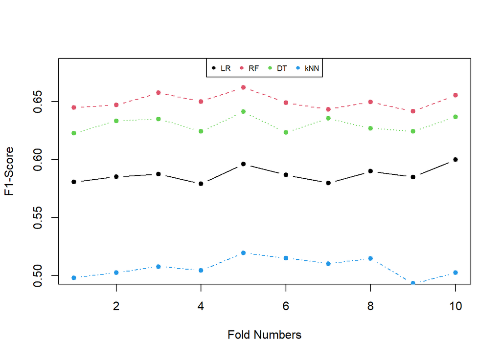

```r
matplot(stability_results[2:5], type=c("b"), pch=19, col=1:4,
        ylab="F1-Score", xlab="Fold Numbers", cex=0.8, xlim=c(1,10),
        ylim=c(0.50, 0.68))
legend("top", legend=c("LR", "RF", "DT", "kNN"), col=1:4, pch=19, cex=0.65, horiz=TRUE)
```

Now, let’s do some parameter tuning to see if we can optimize the random forest model with feature importance and parameter tuning.

```r
#importances.
#sort(importance(rf_model))

#Assessing variable importance with Boruta. Using the last
#train set from the 10-fold cross validation.
boruta_importance <- Boruta(X_RFHLTH ~ ., data=cv.train.set[-42])
print(boruta_importance) #all features important
```

```
## Boruta performed 17 iterations in 59.32195 mins.
##  40 attributes confirmed important: ADDEPEV2, ADULT, AVGDRNK, BEANDAY_,
## BLIND and 35 more;
##  No attributes deemed unimportant.
```

```r
boruta_final <- TentativeRoughFix(boruta_importance)
boruta_results <- attStats(boruta_final)
boruta_results <- boruta_results[order(-boruta_results$meanImp),]
print(boruta_results)
```

```
##              meanImp  medianImp     minImp     maxImp  normHits  decision
## PHYSHLTH  152.839337 152.501968 148.209774 157.540380 1.0000000 Confirmed
## QLACTLM2   85.855081  86.242064  82.453208  87.855409 1.0000000 Confirmed
## X_MICHD    70.717271  69.533316  66.772994  76.637675 1.0000000 Confirmed
## MENTHLTH   64.153488  64.375208  61.007866  67.140824 1.0000000 Confirmed
## CHCCOPD1   63.155852  62.909274  58.794984  67.395849 1.0000000 Confirmed
## USEEQUIP   60.498303  60.292508  56.953225  64.450268 1.0000000 Confirmed
## DIABETE3   60.415067  60.380004  57.771987  64.499840 1.0000000 Confirmed
## X_EDUCAG   57.249121  57.309261  52.608324  61.962633 1.0000000 Confirmed
## X_RACE     53.100041  53.478045  48.680851  56.389920 1.0000000 Confirmed
## DECIDE     46.622583  46.939021  43.301029  49.388379 1.0000000 Confirmed
## INCOME2    43.555152  43.447225  39.739821  46.369132 1.0000000 Confirmed
## EXRACT11   42.987995  42.750497  41.059007  45.090712 1.0000000 Confirmed
## X_VEGESUM  39.172437  38.983318  37.540668  41.881079 1.0000000 Confirmed
## CHCKIDNY   37.976702  38.061448  34.809468  40.111584 1.0000000 Confirmed
## CVDSTRK3   36.465448  36.522670  33.867317  38.671029 1.0000000 Confirmed
## BLIND      36.413860  36.698865  33.731626  38.495749 1.0000000 Confirmed
## AVGDRNK    34.929346  35.218545  32.650902  37.514473 1.0000000 Confirmed
## X_BMI5     32.707687  32.303221  29.875118  36.062057 1.0000000 Confirmed
## EMPLOY1    30.737117  30.540708  28.525221  33.724174 1.0000000 Confirmed
## X_AGEG5YR  29.483253  29.823549  26.124229  32.083049 1.0000000 Confirmed
## MEDCOST    26.621161  26.647471  24.795942  28.353877 1.0000000 Confirmed
## X_RFHYPE5  24.816920  25.045706  22.823158  26.813819 1.0000000 Confirmed
## X_DRDXAR1  24.326271  24.166237  22.534619  28.069009 1.0000000 Confirmed
## BEANDAY_   23.576916  23.501072  21.379280  25.654242 1.0000000 Confirmed
## X_FRUTSUM  22.183497  22.515359  19.739652  24.223661 1.0000000 Confirmed
## SEX        21.281587  21.551395  19.155050  23.054677 1.0000000 Confirmed
## STRNGTH    21.278371  21.267007  19.567969  24.898793 1.0000000 Confirmed
## RENTHOM1   20.041206  20.032016  16.904850  22.274300 1.0000000 Confirmed
## ADDEPEV2   19.797892  19.877591  17.996837  21.458745 1.0000000 Confirmed
## ADULT      18.271647  18.007021  16.183478  21.681159 1.0000000 Confirmed
## MARITAL    18.139963  17.984378  16.649812  20.029261 1.0000000 Confirmed
## X_SMOKER3  17.666839  17.679510  15.394276  21.197139 1.0000000 Confirmed
## X_ASTHMS1  16.709884  17.227074  14.876477  17.827374 1.0000000 Confirmed
## CNCER      16.649878  16.314592  15.377202  19.109144 1.0000000 Confirmed
## VETERAN3   14.917289  15.110941  12.837825  16.301140 1.0000000 Confirmed
## X_RFCHOL    9.169735   9.202358   7.210058  11.260509 1.0000000 Confirmed
## CHECKUP1    7.866867   7.839228   6.031555   9.875951 1.0000000 Confirmed
## CHILDREN    6.900205   6.748029   5.199867   8.383790 1.0000000 Confirmed
## HLTHPLN1    5.824874   5.680126   3.873121   7.745745 1.0000000 Confirmed
## FLUSHOT6    3.713718   3.418939   2.213278   5.640815 0.9411765 Confirmed
```

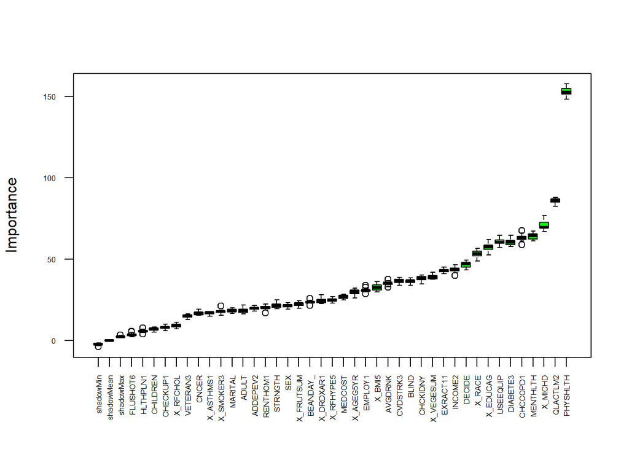

```r
#Visualization
plot(boruta_importance,
     las=2,
     xlab="",
     cex.axis=0.5)
```

Interestingly, there seems to be a theme of mobility surrounding these important features. We’ll look more into these relationships later.

Now let’s do some parameter tuning for random forest with the dataset.

```r
#manual grid creation.
parameter_grid <- expand.grid(
  mtry = 1:4,
  node_size = 1:3,
  num.trees = seq(50,500,50),
  OOB_RMSE = 0
)

#Creating for loop to iterate through grid and apply to ranger.
system.time(
  for(i in 1:nrow(parameter_grid)) {
    # train model
    rf <- ranger(
      formula = X_RFHLTH ~ .,
      data = cv.train.set,
      num.trees = parameter_grid$num.trees[i],
      mtry = parameter_grid$mtry[i],
      min.node.size  = parameter_grid$node_size[i],
      importance = 'impurity')
    # add OOB error to grid
    parameter_grid$OOB_RMSE[i] <- sqrt(rf$prediction.error)
  })
```

```
##     user   system  elapsed
## 17997.47    52.02  1534.11
```

```r
nrow(parameter_grid) # 120 models
```

```
## [1] 120
```

```r
position = which.min(parameter_grid$OOB_RMSE)
head(parameter_grid[order(parameter_grid$OOB_RMSE),],5)
```

```
##     mtry node_size num.trees  OOB_RMSE
## 120    4         3       500 0.3706524
## 108    4         3       450 0.3709880
## 116    4         2       500 0.3710207
## 80     4         2       350 0.3710944
## 112    4         1       500 0.3711025
```

Now, let’s apply our hyperparameters to our 10-fold random forest classification model.

```r
#Creating the empty vectors.
accuracy = rep(0, k)
specificity = rep(0, k)
precision = rep(0, k)
sensitivity = rep(0,k)
fscore = rep(0, k)
runningtime = rep(0, k)

#Training, testing, and recording accuracy measures of a
#random forest classification for each k fold.
for(i in 1:k){
  cv.train.set = data_norm_imp[data_norm_imp$fold != i,]
  cv.test.set = data_norm_imp[data_norm_imp$fold == i,]

  start <- Sys.time()
  rf_model <- ranger(X_RFHLTH ~ ., data=cv.train.set[-42],
                     importance="impurity",
                     num.trees = 500,
                     probability = FALSE,
                     min.node.size = 2,
                     mtry = 4)

  end <- Sys.time()
  time <- end - start
  runningtime[i] = time

  predictions <- predict(rf_model, cv.test.set[-42])$predictions

  cm <- table(predicted=predictions, actual=cv.test.set$X_RFHLTH)

  accuracy[i] = sum(cm[1], cm[4]) / sum(cm[1:4])
  specificity[i] = cm[1] / sum(cm[1], cm[2])
  precision[i] = cm[4] / sum(cm[4], cm[2])
  sensitivity[i] = cm[4] / sum(cm[4], cm[3])
  fscore[i] = (2 * (sensitivity[i] * precision[i]))/(sensitivity[i] + precision[i])
}

#Averaging the performance metrics.
rf_metrics_tuned <- c(mean(accuracy), mean(specificity), mean(precision), mean(sensitivity), mean(fscore), mean(runningtime))
print(cm)
```

```
##          actual
## predicted     0     1
##         0 13612  1768
##         1   745  2336
```

```r
print(rf_metrics_tuned)
```

```
## [1]  0.8626921  0.9505019  0.7630315  0.5562303  0.6433742 32.7743234
```

Hyperoptimization did not have a significant impact on the accuracy of the model.